# Healthcare Application: Colorectal Cancer Survival Analysis

[figure not shown]

# Healthcare Application: Colorectal Cancer Survival Analysis

Kyle Admire, Travis Frocione, Tashuna Jackson, Xenia Liu, Le Nhan, Megan Williams

2023-01-08

## Introduction

**Survival Analysis studies time-to-event data, where our response variable indicates how long it takes for an event to happen.**

**This technique is very common in healthcare, and it is often measured when patients from a certain risk group die, which is why it is called survival analysis.**

**Additionally, in healthcare, people are allowed to quit participating in a study, so a large portion of the data is actually hidden from us. Because of this, we cannot use another classification method. In survival analysis, the response is the time-to-event and whether or not we observed the event take place.**

**For this reason, different models need to be used. In this study, we will use two different models: the Kaplan Meier model, and the Cox-Proportional Hazards model.**

**The example dataset we will use is colorectal cancer data, which tracks the time before at-risk patients contract colorectal cancer. This dataset includes gene expression data, and its size makes it difficult to use in traditional statistics, so we will use PCA and LASSO to reduce the number of variables in our model.**

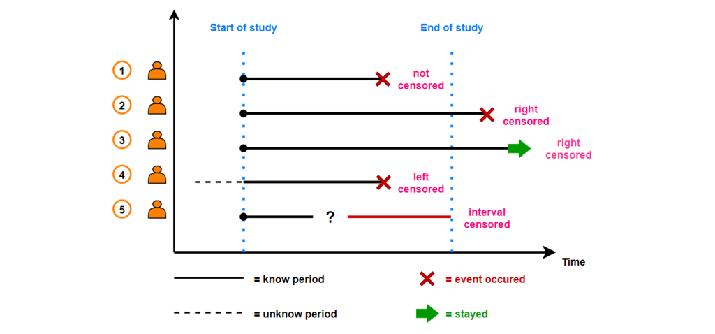

Censor

## Kaplan-Meier Model

**The survival function can be expressed mathematically as the Probability that the duration is longer than t, or as 1 minus the probability of Failure for duration longer than t**

$$S(t) = 1 - F(t) = P(T>t)$$
**The Kaplan-Meier model simply looks at the time at which the patients contracted colorectal cancer. Additionally, we can compare different groups of patients to determine how they contracted colorectal cancer at different rates.**

**Below, the the colorectal cancer patients are divided into groups by gender.**

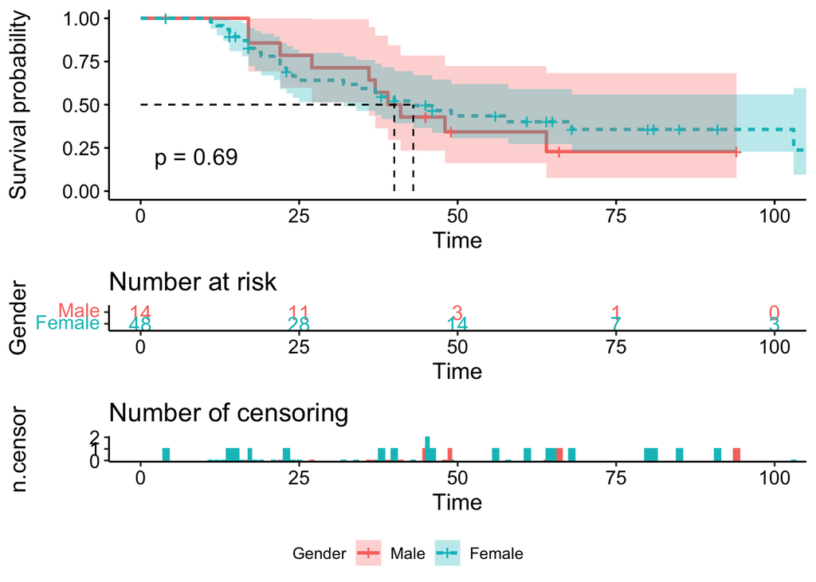

## PCA and LASSO

**Now, if we want to compare how the genes of the colorectal cancer patients may have affected the cancer contract rate, we can use the Cox-Proportional Hazards model. However, this model can only be used when the number of variables is small, so we need to reduce the number of gene expression variables in the dataset, which can be accomplished with PCA or LASSO.**

**PCA is an unsupervised dimension reduction technique that clusters similar variables together according to how much variance that the variables explain in the dataset.**

**LASSO is a regularization method that can be used as a variable selector. It will fit the usual linear regression with an extra constraint that limits how many variables will be used for the model. The mathematical equation for it is shown below.**

$$\hat\beta = \arg \min_{\beta} \left\{-\sum_{i=1}^n (y- X^T\beta) +
\lambda \sum_{i=1}^p |\beta| \right\}$$

**Each of these methods will use the Cox-Proportional Hazards model, and we will compare the results.**

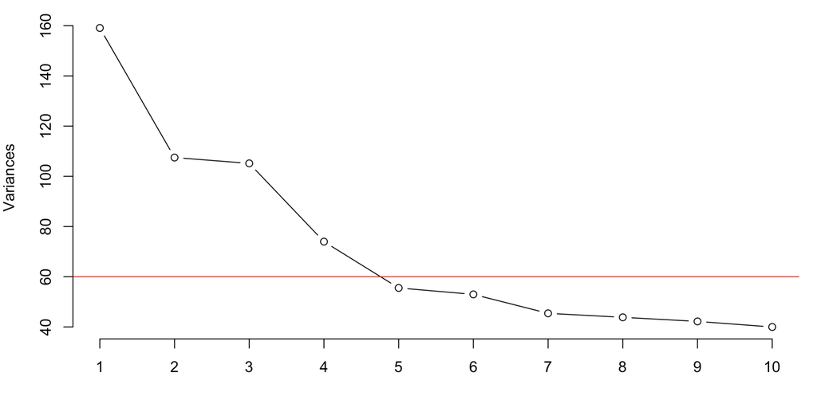

PCA Scree Plot

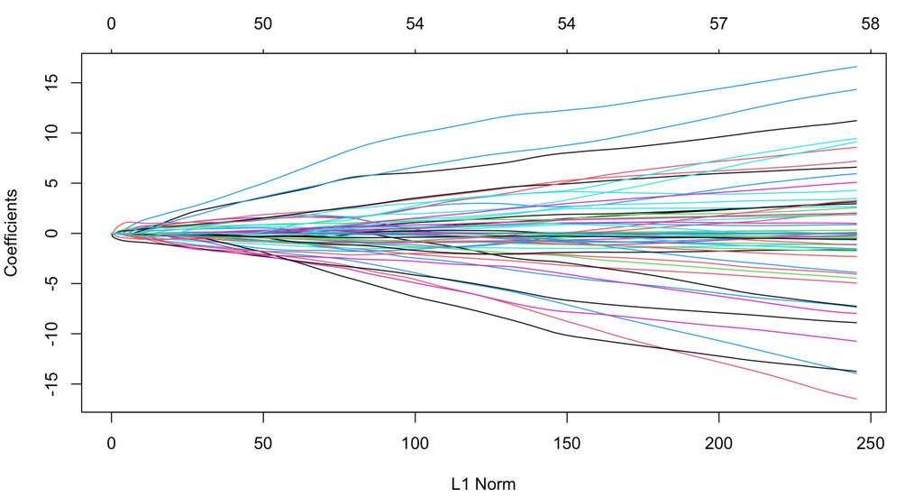

LASSO L1 Norm Plot

## Survival Analysis Prediction

**Now that the number of variables are reduced, we can use the Cox-proportional hazards model. Machine learning and cross-fold validation can also be used to pick the model that best predicts when patients could possibly contract colorectal cancer. This is done by dividing the data into a training set and a testing set to see which model can make the best predictions.**

**For the cox-proportional hazards model, we use the concordance index to show prediction accuracy, which outlines how well the gene expression variables can help predict the order in which the patients will contract colorectal cancer.**

Concordance Index:

$$C = \frac{\sum_{i\in U}\{\sum_{T_j > T_i}1_{f_j >
f_i}\}}{\sum_{i\in U}\{\sum_{T_j > T_i}1\}}$$
where U is the a set of uncensored data.$T_i$ is an observed survival time of sample i.$f_i$ is a predicted survival time of sample i. $1_{a>b}$= 1 if a>b, and 0 otherwise.

**A concordance index of around 1 indicates a great model. A concordance index approximately 0.5 shows a model that is less ideal. We can calculate the concordance index of this model using a different number of variables. The results are shown below.**

**Unfortunately, it is difficult to show the results of this model visually. Instead, a math formula is used.**

$$h_i(t,x | \beta) = h_o(t) \exp(X^T\beta)$$
Where $h_i(t)$ is the hazard function for individual i. $h_o(t)$ is the baseline hazard function. X are the covariates and $\beta$ are the regression coefficents estimated

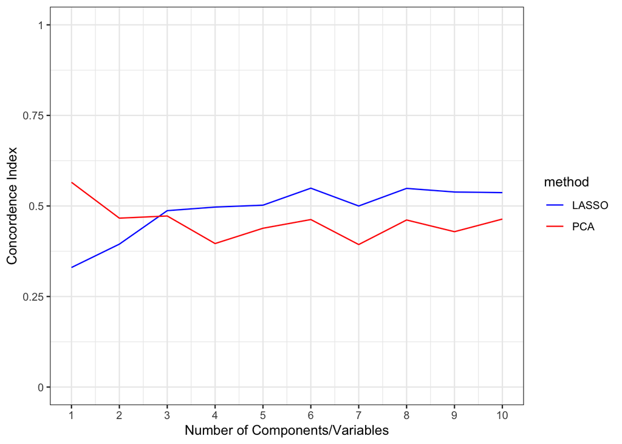

**We tracked how well the cox-proportional hazards model performed using 1 to 10 different variables as the PCA components or the LASSO-selected variables. The results implied that these gene expressions could not predict whether or not when some patients contracted colorectal cancer. This information could be helpful to healthcare professionals.**